# IECD 2C2024 - Clase 2 - QQ Plots

Gonzalo Barrera

2024-08-17

# Actividad

0. Descubra la humanidad en el ser más cercano a usted. Pregúntele su nombre si no lo sabe, si tiene mascotas y cuál es su helado favorito. Realicen juntos las actividades siguientes, alentándose mutuamente, durante 30 minutos. Anoten sus dudas y triunfos como para compartir durante la exposición posterior de la cátedra.
1. 1. Escriba una función `mi_qqnorm`, que tome como único parámetro un vector numérico `x`, y genere un gráfico idéntico al que resulta al llamar `qqnorm(x)`.
   2. En un único plot, realice dos subplots: `qqnorm(slong)` y `mi_qqnorm(slong)`, donde `slong` contiene la longitud de los sépalos de la especie “setosa” de flores `iris`.
2. 1. Realice el mismo gráfico, pero utlizando la librería `ggplot2`. Sugerencia: utilice la geometría `geom_qq`.
   2. Encadenando comandos de las librerías del `tidyverse` y `ggplot2`, parta del dataset `iris` y genere el mismo gráfico que en (1a). Sugerencia: considere el operador “cañería” `%>%`.
3. Agregue un parámetro opcional `linea` a la función `mi_qqnorm`, por defecto falso, que cuando se setea a `TRUE`, agregue una recta idéntica a la que `qqline` añade a `qqnorm`. Sugerencia: considere la función `abline` y el control de flujo `if (condicion) { ... }`.
4. Usando `ggplot2`, realice un gráfico cuantil-cuantil normal, de la longitud de sépalo *de las tres especies a la vez*, con su correspondiente leyenda. Interprete. Sugerencia: considere el parámetro `color` al definir el “mapeo de estéticas” del gráfico.

# Exposición

## QQ Plot, el gráfico que llora

De [Wikipedia](https://en.wikipedia.org/wiki/Q%E2%80%93Q_plot) > In statistics, a Q–Q plot (quantile–quantile plot) is a probability plot, a graphical method for comparing two probability distributions by plotting their quantiles against each other.

En el fondo es un gráfico de dispersión (*scatterplot*) para los *cuantiles* de dos distribuciones, teóricas o empíricas (aunque usualmente al menos una será empírica.

```r
head(iris)
```

```
##   Sepal.Length Sepal.Width Petal.Length Petal.Width Species
## 1          5.1         3.5          1.4         0.2  setosa
## 2          4.9         3.0          1.4         0.2  setosa
## 3          4.7         3.2          1.3         0.2  setosa
## 4          4.6         3.1          1.5         0.2  setosa
## 5          5.0         3.6          1.4         0.2  setosa
## 6          5.4         3.9          1.7         0.4  setosa
```

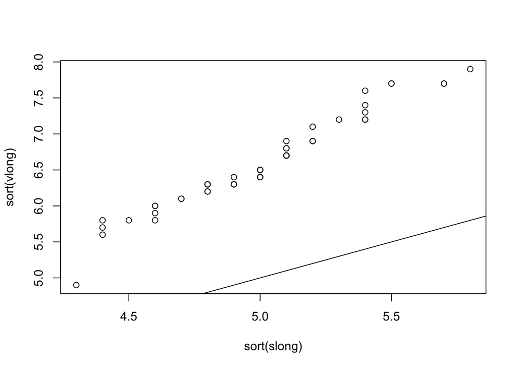

```r
long <- iris$Sepal.Length
slong <- long[iris$Species == "setosa"]
vlong <- long[iris$Species == "virginica"]

plot(sort(slong), sort(vlong))
abline(a=0, b=1)
```

## `qqnorm`: ¿tienen pinta de normales estos datos?

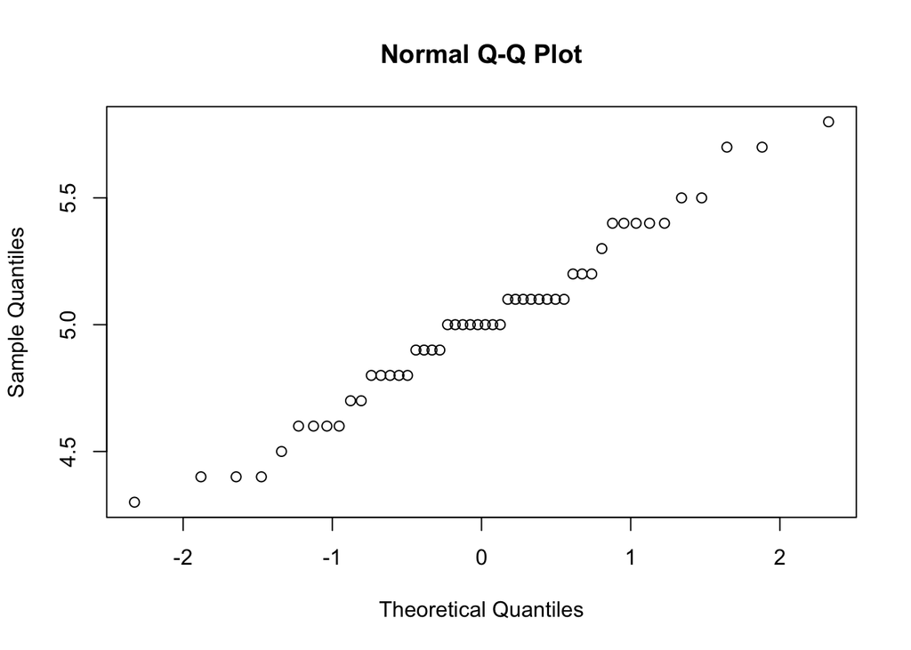

```r
qqnorm(slong)
```

Nótese que el eje $x$ tiene cuantiles *teóricos*, y el eje $y$ tiene cuantiles *muestrales* (o empíricos). Estamos comparando una distribución empírica (cuya “verdadera” distribución desconocemos) con una distribución teórica, en este caso la normal.

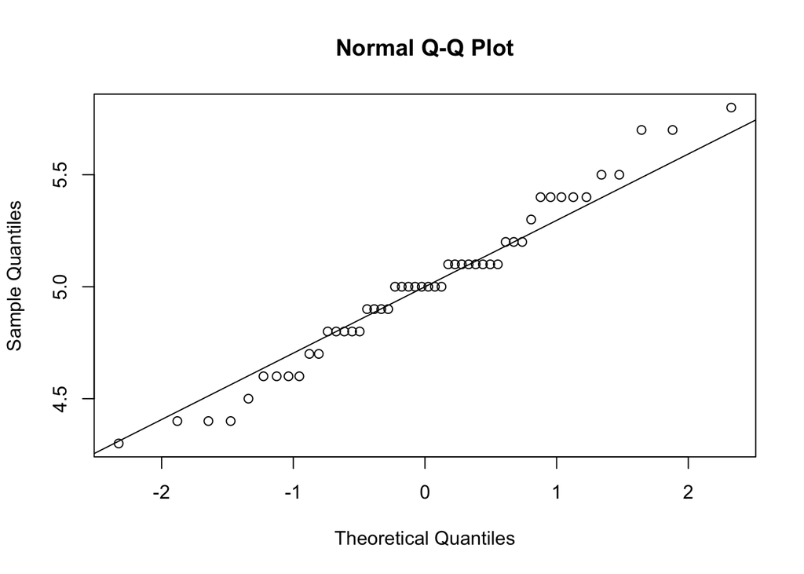

```r
qqnorm(slong)
qqline(slong)
```

## Pero, ¿qué es un cuantil, en serio?

Conocemos distintas maneras de describir una v.a. $X$: su función de densidad (o probabilidad) $f$ (AKA `pdf`), su función de distribución (acumulada) $F$, su función característica…

La función de *cuantiles* (llamémosla $Q$) es la *inversa* de la función de distribución:
$$Q(t) = s \iff F(s) = t$$

### Para otro día `ecdf`: función de distribución empírica

```r
F_slong <- ecdf(slong)
q <- 5.1
F_slong(q)
```

```
## [1] 0.72
```

```r
mean(slong <= q)
```

```
## [1] 0.72
```

¿Pero como escribo “la inversa” de `ecdf`? Una versión sencilla: evaluarla únicamente en los puntos conocidos:

```r
cuantiles <- sort(slong)
n <- length(slong)
names(cuantiles) <- 1:n / n
cuantiles["0.02"]
```

```
## 0.02
##  4.3
```

Medio trucho, ¿no? **Tarea para el hogar: escriba una función `Q_empirica(x)`, que dada una muestra `x` devuelva la función de cuantiles empíricos correspondiente a `x`.** Pregunta para la clase: ¿es necesario tanto? ¿Qué cuantiles empíricos ya conocemos? ¿Y qué cuantiles teóricos necesitamos conocer?

### `[q|d|p|r]norm`: operando con variables aleatorias en `R`

Sea `<dist>` el nombre de una distribución (`norm`al, `exp`onencial, `unif`orme, et cetera) en R. Luego, - `d<dist>` representa su función de *densidad* $f$ (`pdf`) - `p<dist>`, su función de *distribución* $F$ (`cdf`) - `q<dist>`, su función de *cuantiles* $Q$ (`ppf`) - `r<dist>`, su función generadora aleatoria (`rvs`)

```r
help(qunif)
```

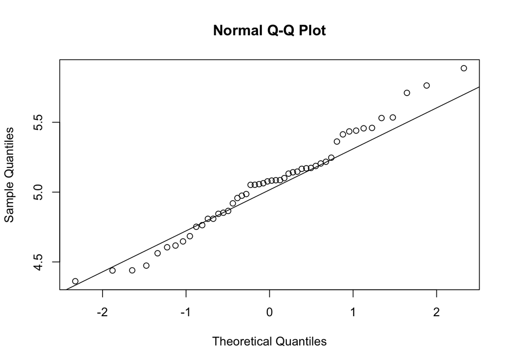

```r
ruido <- runif(length(slong), 0, 0.25 * sd(slong))
qqnorm(slong + ruido)
qqline(slong + ruido)
```

## Reproduciendo `qqnorm`

```r
help(qqnorm)
```

### `ppoints`: Los cuantiles empíricos están *enfermos* (ill-defined)

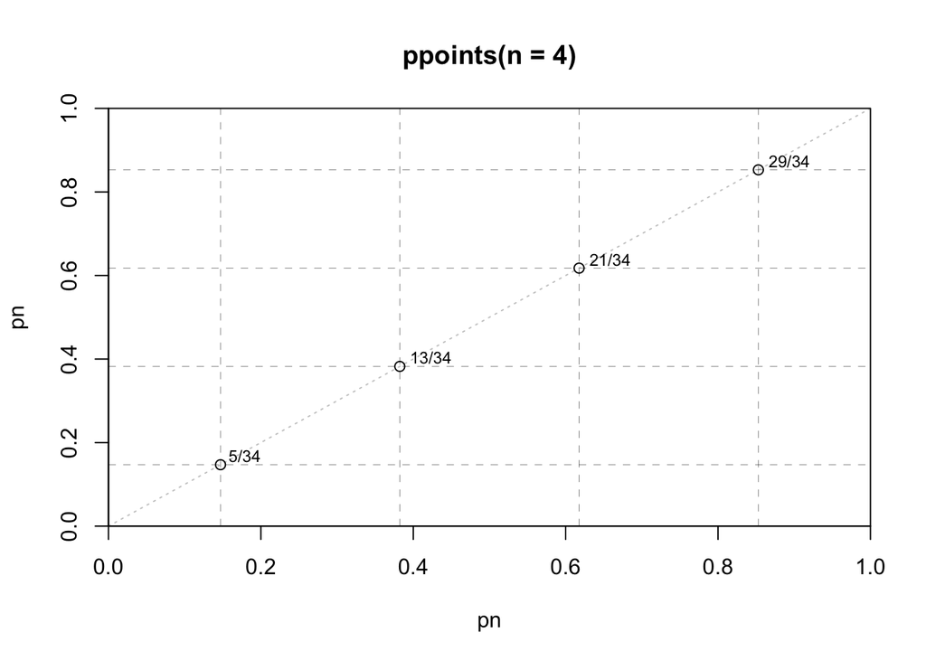

```r
help(ppoints)

require(graphics)
p.ppoints <- function(n, ..., add = FALSE, col = par("col")) {
  pn <- ppoints(n, ...)
  if(add)
    points(pn, pn, col = col)
  else {
    tit <- match.call(); tit[[1]] <- quote(ppoints)
    plot(pn,pn, main = deparse(tit), col=col,
         xlim = 0:1, ylim = 0:1, xaxs = "i", yaxs = "i")
    abline(0, 1, col = adjustcolor(1, 1/4), lty = 3)
  }
  if(!add && requireNamespace("MASS", quietly = TRUE))
    text(pn, pn, as.character(MASS::fractions(pn)),
         adj = c(0,0)-1/4, cex = 3/4, xpd = NA, col=col)
  abline(h = pn, v = pn, col = adjustcolor(col, 1/2), lty = 2, lwd = 1/2)
}

p.ppoints(4)
```

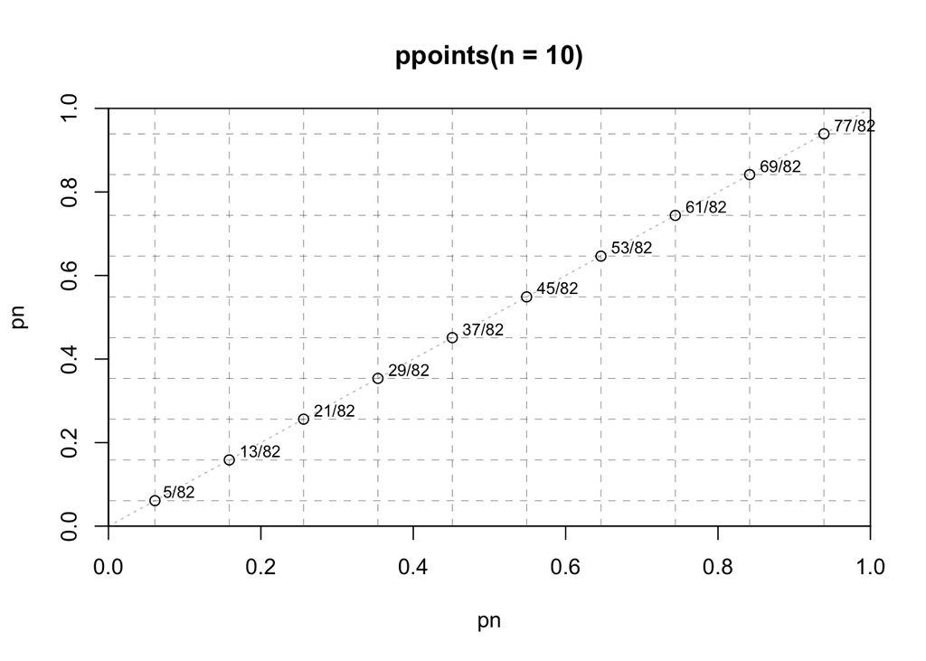

```r
p.ppoints(10)
```

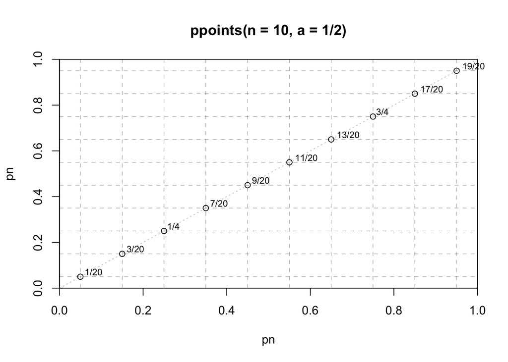

```r
p.ppoints(10, a = 1/2)
```

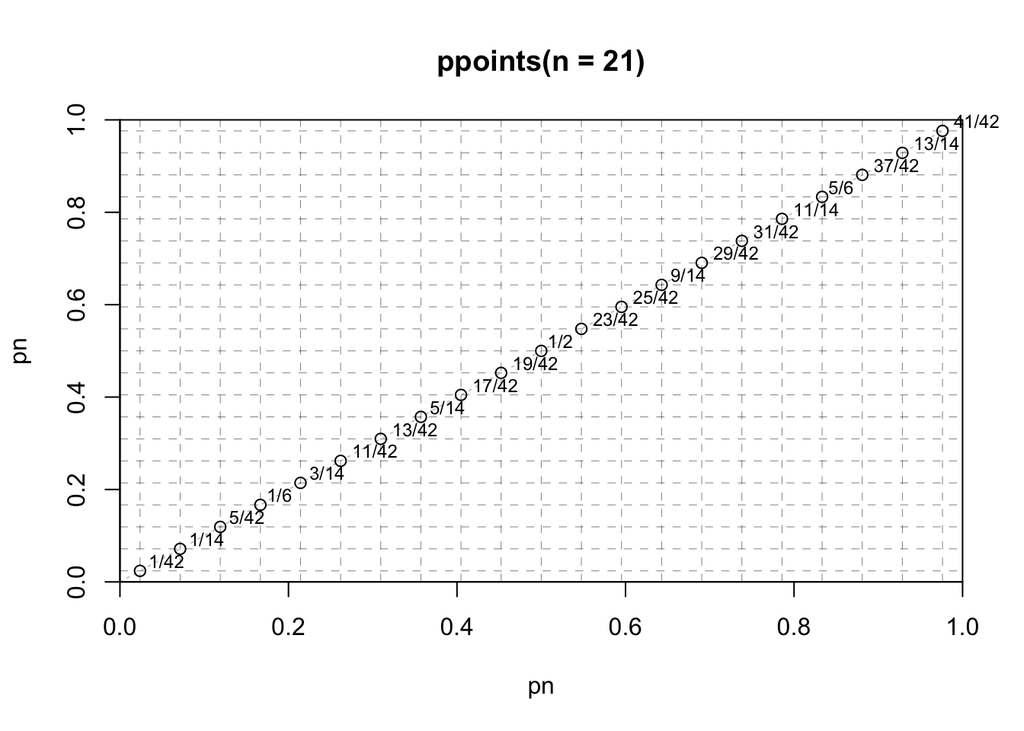

```r
p.ppoints(21)
```

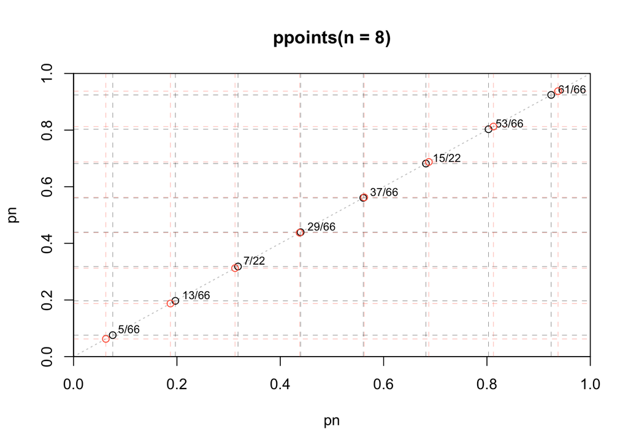

```r
p.ppoints(8) ; p.ppoints(8, a = 1/2, add=TRUE, col="tomato")
```

Cuando $a = 1/2$, ppoints se simplifica a $\dfrac{2 \times (1:n) - 1}{2n}$

```r
n <- length(slong)
mis_ppoints <- (2*(1:n) - 1) / (2*n)
R_ppoints <- ppoints(n, a=1/2)
stopifnot(all(mis_ppoints == R_ppoints))
```

## Ahora sí, una primera versión

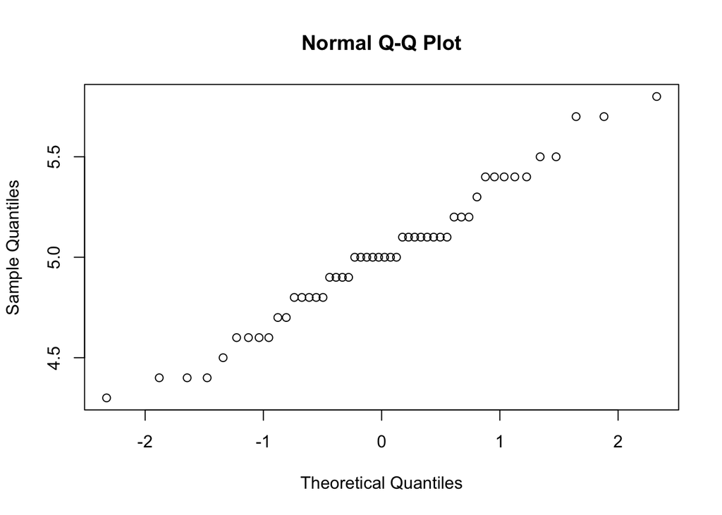

```r
qqnorm(slong)
```

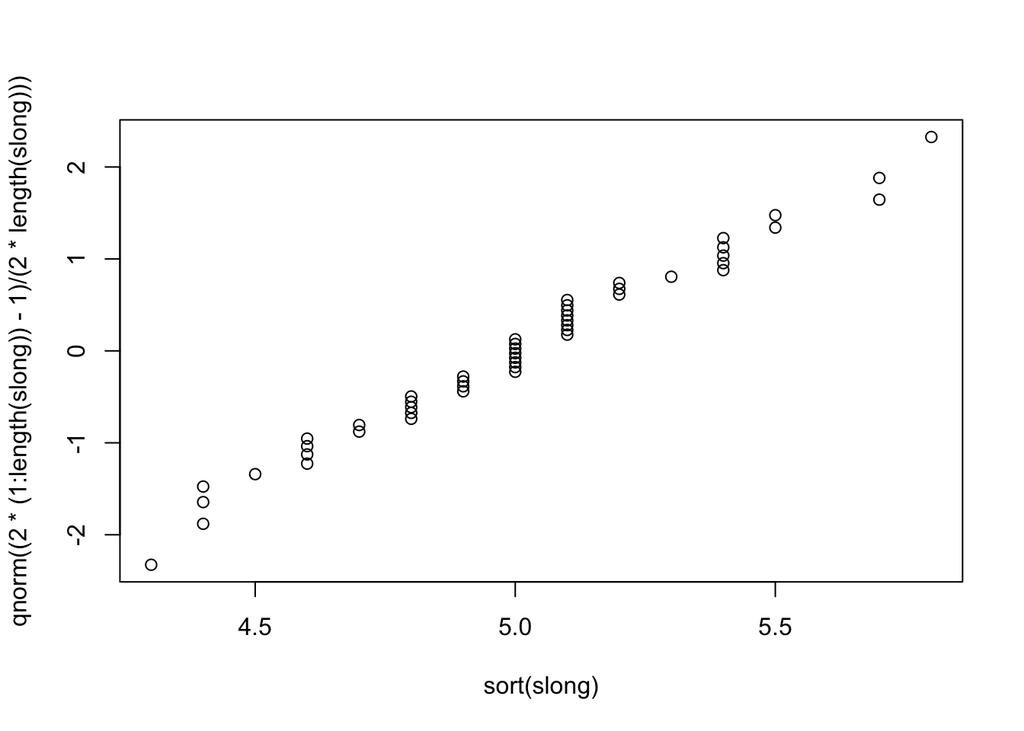

```r
plot(
    x=sort(slong), y=qnorm((2*(1:length(slong)) - 1) / (2*length(slong)))
)
```

Un poco más prolijo: - DRY (“don’t repeat yourself”): si una cantidad la necesito dos veces, se asigna a una variable y se reusa, - los ejes están invertidos - los nombres de los ejes no son informativos - no tiene título

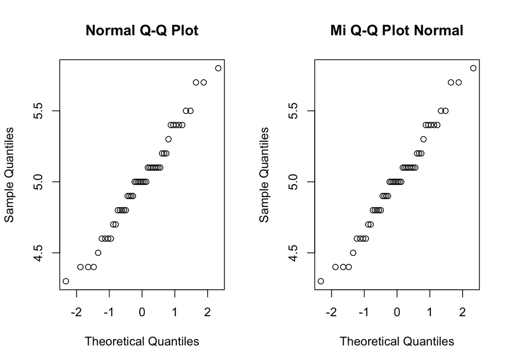

```r
mi_qqnorm <- function(x) {
  n <- length(x)
  plot(
    x=qnorm((2*(1:length(x)) - 1) / (2*length(x))),
    y=sort(x),
    main="Mi Q-Q Plot Normal",
    xlab="Theoretical Quantiles",
    ylab="Sample Quantiles"
  )
}

par(mfrow = c(1, 2))
qqnorm(slong)
mi_qqnorm(slong)
```

Hermanxs, hemos compartido la práctica, pueden ir en paz.

## Chapoteando en el tidyverse con un flota flota de Internet

Una heurística para *aprender* y no sólo *reproducir*: - **SÍ** lean la documentación oficial - **SÍ** aprendan a buscar en Google (sugerencia: StackOverflow hasta Diciembre 2022) - **NO** usen ChatGPT/Copilot/LLMs sin chequear por triplicado. Y aun así, duden.

Todo lo que tienen que saber de R de acá a que se reciban (y más de lo que saben sus profesores, quien les habla incluido): - [Hands-On Programming With R](https://rstudio-education.github.io/hopr/) - [R for Data Science (en)](https://r4ds.hadley.nz/) - [R para Ciencia de Datos (es)](https://es.r4ds.hadley.nz/) - [Tidyverse](https://www.tidyverse.org/) - [ggplot2: Elegant Graphics for Data Analysis (3e)](https://ggplot2-book.org/) - [Tidy Modeling with R](https://www.tmwr.org/)

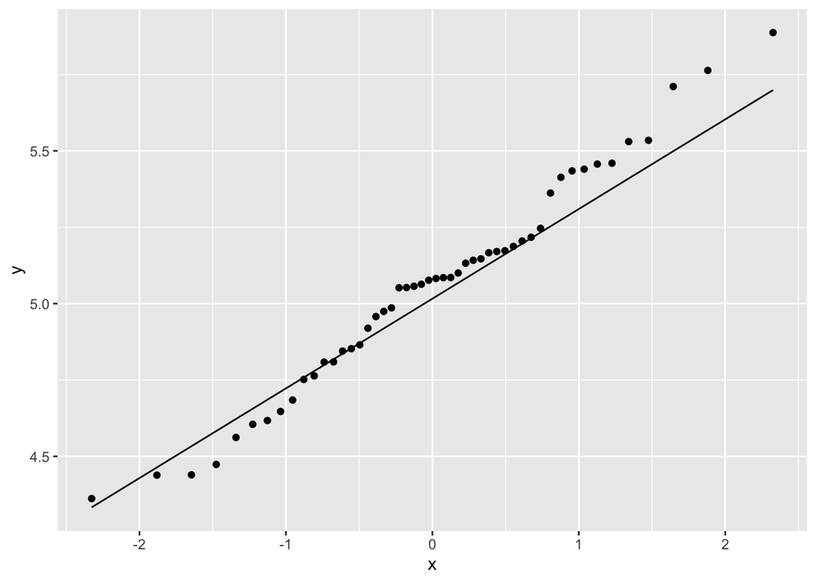

```r
# install.packages(c("ggplot2", "tidyverse"))
# https://ggplot2.tidyverse.org/articles/ggplot2.html
library(tidyverse)
iris %>%
  filter(Species == "setosa") %>%
  select(Sepal.Length) %>%
  mutate(x=Sepal.Length + ruido) %>%
  ggplot(aes(sample=x)) +
  geom_qq() +
  geom_qq_line()
```